# Assignment3-CNN-RNN-Group15

## Advanced Machine Learning - Assignment 3 - CNN and RNN

### Trang Vu, Jenny Khanh, Aditi Gala

### Apr 30, 2020

```python
# Import libraries
import tensorflow as tf
from tensorflow import keras

import keras
from keras import models
from keras.models import Sequential
from keras import layers
from keras.layers import Dense, Dropout, LSTM, GRU, Flatten
from keras.layers import Input, MaxPooling1D, Conv1D
from keras.models import Model

from keras import optimizers
from keras.datasets import mnist
from keras.utils import to_categorical
from keras.callbacks import ModelCheckpoint, EarlyStopping, History


import numpy as np
import pandas as pd
import matplotlib.pyplot as plt
from sklearn.preprocessing import MinMaxScaler
from sklearn.model_selection import train_test_split
import sklearn.metrics as metrics


# Set seed
np.random.seed(123)
```

## Problem 1)

### Image Classification

The selected dataset is [Fashion MINST](https://github.com/zalandoresearch/fashion-mnist). Each sample in the F-MINST dataset is a 28 by 28 grayscale image from 10 "fashion" classes. There are a total of 60,000 training images and 10,000 test images. We use the data to train & validate a Convolutional Neural Network (CNN) model that can classify these images based on their pixel values.

```
Dimension of the training input is: (60000, 28, 28)
Dimension of the test input is: (10000, 28, 28)
Dimension of the training target is: (60000,)
Dimension of the test target is: (10000,)
```

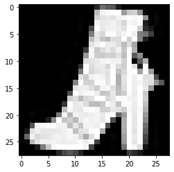

```python
# Import the Fashion MINST dataset from Keras
fashion_mnist = keras.datasets.fashion_mnist
(X_train, Y_train), (X_test, Y_test) = fashion_mnist.load_data()

print('Dimension of the training input is:', X_train.shape)
print('Dimension of the test input is:', X_test.shape)
print('Dimension of the training target is:', Y_train.shape)
print('Dimension of the test target is:', Y_test.shape)

# See example image
plt.imshow(X_train[11], cmap = 'gray')
plt.show()
```

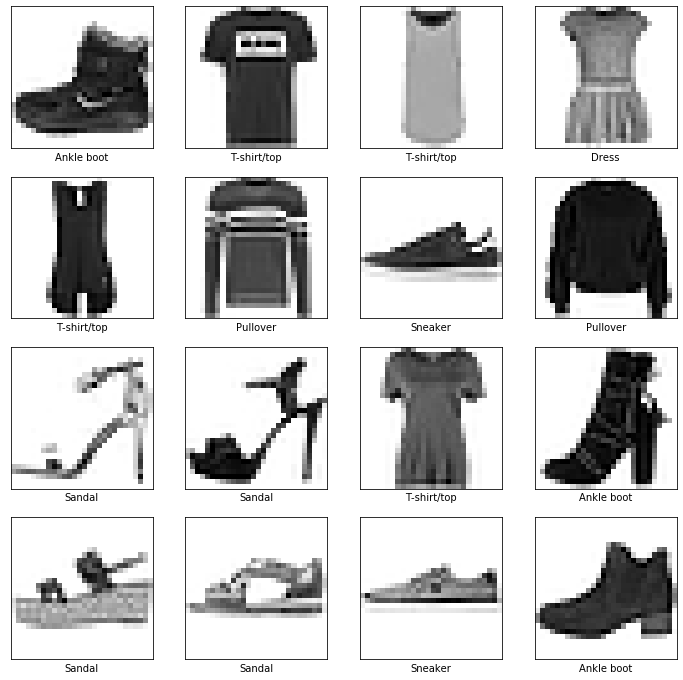

```python
class_names = ['T-shirt/top', 'Trouser', 'Pullover', 'Dress', 'Coat',
               'Sandal', 'Shirt', 'Sneaker', 'Bag', 'Ankle boot']

# Let's display 16 images to verify if they are in correct format
plt.figure(figsize=(12,12))
for i in range(16):
    plt.subplot(4,4,i+1)
    plt.xticks([])
    plt.yticks([])
    plt.grid(False)
    plt.imshow(X_train[i], cmap=plt.cm.binary)
    plt.xlabel(class_names[Y_train[i]])
plt.show()
```

```python
# Preprocessing
X_train = X_train.reshape((60000, 28, 28, 1))
X_test = X_test.reshape((10000, 28, 28, 1))

X_train = X_train.astype('float32')
X_test = X_test.astype('float32')

X_train /= 255
X_test /= 255

# preprocess (one-hot encoding), dumifying categorical data
Y_train = to_categorical(Y_train)
Y_test = to_categorical(Y_test)


print('Dimension of the training input is:', X_train.shape)
print('Dimension of the test input is:', X_test.shape)
print('Dimension of the training target is:', Y_train.shape)
print('Dimension of the test target is:', Y_test.shape)
```

```
Dimension of the training input is: (60000, 28, 28, 1)
Dimension of the test input is: (10000, 28, 28, 1)
Dimension of the training target is: (60000, 10)
Dimension of the test target is: (10000, 10)
```

```python
# Instantiating the CNN
model = models.Sequential()

# Add the 3 sets of convolutional layers with pooling layers in between
model.add(layers.Conv2D(filters = 32,
                        kernel_size = (3,3),
                        activation = 'relu',
                        input_shape = (28, 28, 1)))
model.add(layers.MaxPooling2D(pool_size = (2,2)))
model.add(layers.Conv2D(filters = 64,
                        kernel_size = (3,3),
                        activation = 'relu'))
model.add(layers.MaxPooling2D(pool_size = (2,2)))
model.add(layers.Conv2D(filters = 64,
                        kernel_size = (3,3),
                        activation = 'relu'))

# Add the fully connected dense layer, which processes 1D vectors, thus we must flatten output
model.add(layers.Flatten())
model.add(layers.Dense(units = 64, activation = 'relu'))
model.add(layers.Dense(units = 10, activation = 'softmax'))

# loss funtcion
model.compile(loss = 'categorical_crossentropy', optimizer = 'RMSprop', metrics = ['accuracy'])

model.summary()
```

```
Model: "sequential_1"
_________________________________________________________________
Layer (type)                 Output Shape              Param #
=================================================================
conv2d_1 (Conv2D)            (None, 26, 26, 32)        320
_________________________________________________________________
max_pooling2d_1 (MaxPooling2 (None, 13, 13, 32)        0
_________________________________________________________________
conv2d_2 (Conv2D)            (None, 11, 11, 64)        18496
_________________________________________________________________
max_pooling2d_2 (MaxPooling2 (None, 5, 5, 64)          0
_________________________________________________________________
conv2d_3 (Conv2D)            (None, 3, 3, 64)          36928
_________________________________________________________________
flatten_1 (Flatten)          (None, 576)               0
_________________________________________________________________
dense_1 (Dense)              (None, 64)                36928
_________________________________________________________________
dense_2 (Dense)              (None, 10)                650
=================================================================
Total params: 93,322
Trainable params: 93,322
Non-trainable params: 0
_________________________________________________________________
```

```python
# Callback_list
callback_list = [EarlyStopping(monitor = 'val_loss', patience = 3, mode = 'min'),
                 ModelCheckpoint("convNN-epoch-{epoch:02d}-valLoss-{val_loss:.4f}.hdf5", monitor='val_loss',verbose = 2, save_best_only = True, mode = 'min')]

# fit the model
history = model.fit(X_train, Y_train, batch_size = 128, epochs = 20, validation_split = 1/6, verbose = 1, callbacks = callback_list)
```

```
Train on 50000 samples, validate on 10000 samples

Epoch 00001: val_loss improved from inf to 0.53567, saving model to convNN-epoch-01-valLoss-0.5357.hdf5

Epoch 00002: val_loss improved from 0.53567 to 0.35674, saving model to convNN-epoch-02-valLoss-0.3567.hdf5

Epoch 00003: val_loss improved from 0.35674 to 0.32883, saving model to convNN-epoch-03-valLoss-0.3288.hdf5

Epoch 00004: val_loss improved from 0.32883 to 0.31687, saving model to convNN-epoch-04-valLoss-0.3169.hdf5

Epoch 00005: val_loss improved from 0.31687 to 0.29518, saving model to convNN-epoch-05-valLoss-0.2952.hdf5

Epoch 00006: val_loss improved from 0.29518 to 0.29205, saving model to convNN-epoch-06-valLoss-0.2921.hdf5

Epoch 00007: val_loss improved from 0.29205 to 0.25687, saving model to convNN-epoch-07-valLoss-0.2569.hdf5

Epoch 00008: val_loss did not improve from 0.25687

Epoch 00009: val_loss did not improve from 0.25687

Epoch 00010: val_loss did not improve from 0.25687
```

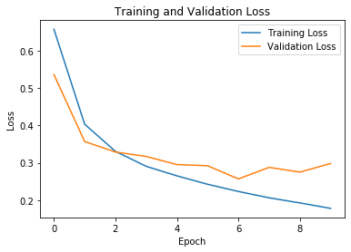

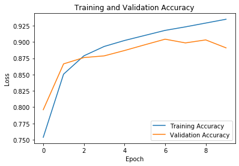

```python
plt.plot(history.history['loss'],label='Training Loss')
plt.plot(history.history['val_loss'], label='Validation Loss')
plt.ylabel('Loss')
plt.xlabel('Epoch')
plt.legend(loc='upper right')
plt.title('Training and Validation Loss')
plt.show()

plt.plot(history.history['accuracy'],label='Training Accuracy')
plt.plot(history.history['val_accuracy'], label='Validation Accuracy')
plt.ylabel('Loss')
plt.xlabel('Epoch')
plt.legend(loc='lower right')
plt.title('Training and Validation Accuracy')
plt.show()
```

#### 1.3) Report the model accuracy on the test set. Include the confusion matrix

```python
# Conv net accuracy
best_model = models.load_model('convNN-epoch-12-valLoss-0.2533.hdf5')

test_loss, test_acc = best_model.evaluate(X_test, Y_test)
print('\nModel performance on test set: test loss = ', round(test_loss, 4), ' and test accuracy = ', round(test_acc, 4))
```

```
Model performance on test set: test loss =  0.2726  and test accuracy =  0.9061
```

```python
# Create Confusion Matrix
pred = best_model.predict(X_test)
pred_class = pred.argmax()

pred = best_model.predict(X_test.reshape(10000, 28, 28, 1))
pred_class = []
for i in range(len(pred)):
    pred_class.append(pred[i].argmax())

class_labels = np.argmax(Y_test, axis=1)
pred_class = np.array(pred_class)

report = metrics.confusion_matrix(class_labels, pred_class)
print("The confusion matrix of the model as below:\n", report)
```

```
The confusion matrix of the model as below:
 [[795   0  17  16   6   1 159   0   6   0]
 [  1 981   1  11   2   0   2   0   2   0]
 [ 10   0 845   8  68   0  69   0   0   0]
 [ 13   8  10 924  20   0  24   0   1   0]
 [  0   0  31  30 899   0  36   0   4   0]
 [  0   0   0   0   0 984   0   8   0   8]
 [ 77   1  54  20  89   0 753   0   6   0]
 [  0   0   0   0   0  21   0 929   1  49]
 [  0   0   2   5   5   2   3   4 979   0]
 [  1   0   0   0   0   3   0  24   0 972]]
```

```python
report = metrics.classification_report(class_labels, pred_class)
print(report)
```

```
              precision    recall  f1-score   support

           0       0.89      0.80      0.84      1000
           1       0.99      0.98      0.99      1000
           2       0.88      0.84      0.86      1000
           3       0.91      0.92      0.92      1000
           4       0.83      0.90      0.86      1000
           5       0.97      0.98      0.98      1000
           6       0.72      0.75      0.74      1000
           7       0.96      0.93      0.95      1000
           8       0.98      0.98      0.98      1000
           9       0.94      0.97      0.96      1000

    accuracy                           0.91     10000
   macro avg       0.91      0.91      0.91     10000
weighted avg       0.91      0.91      0.91     10000
```

## Problem 2)

### Predictions for Admissions data

We use the data from "admData20.csv" to predict the cumulative no. of students admitted 1 - 5 weeks in the future from the current week. Three different model approaches are used and then compared:

1. RNN (both GRU and LSTM compared)
2. 1D CNN, 1D CNN + LSTM, 1D CNN + GRU
3. Deep NN

```python
# Load admissions data
df = pd.read_csv("admData20.csv")
print("Shape of the dataframe: ", df.shape)
df.head()
```

```
Shape of the dataframe:  (147, 5)
```

|  | ExpStartDate | AdmittedNum | AppliedNum | WeeksBeforeStart | Budget |
| --- | --- | --- | --- | --- | --- |
| 0 | 10/29/2018 | 3 | 61 | 10 | 87 |
| 1 | 10/29/2018 | 7 | 84 | 9 | 87 |
| 2 | 10/29/2018 | 10 | 90 | 8 | 87 |
| 3 | 10/29/2018 | 24 | 118 | 7 | 87 |
| 4 | 10/29/2018 | 39 | 132 | 6 | 87 |

### 2.1) Recurrent Neural Network (GRU vs. LSTM)

```python
# Select variable for prediction
adm = df['AdmittedNum'].values

# Split into train, val and test set and normalize data.
# We use 60% of the data for training, 20% for validation, and 20% for test

trainPortion = round(adm.shape[0]*0.6)
valPortion = round(adm.shape[0]*0.2)

trainData = adm[:trainPortion] # Beginning to T rain portion
valData = adm[trainPortion: trainPortion+valPortion] # Train portion to Train+Val portion
testData = adm[trainPortion+valPortion:] # Train+Val portion to end

print("We have %d training, %d validation, and %d test data points. " % (len(trainData), len(valData), len(testData)))

# Normalize Data
sc = MinMaxScaler(feature_range=(0,1))

# Reshape data to a 2D array from a 1D array
trainData = trainData.reshape(-1,1)
valData = valData.reshape(-1,1)
testData = testData.reshape(-1,1)

print(trainData.shape, valData.shape, testData.shape)

sc.fit(trainData)
trainNorm = sc.transform(trainData)
valNorm = sc.transform(valData)
testNorm = sc.transform(testData)
```

```
We have 88 training, 29 validation, and 30 test data points.
(88, 1) (29, 1) (30, 1)
```

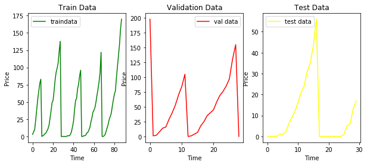

```python
# Subplot with training data
plt.figure(figsize=(10, 4))
plt.subplot(1,3,1)
plt.plot(range(trainData.shape[0]),trainData, color = 'green',label = "traindata")
plt.title('Train Data')
plt.xlabel('Time')
plt.ylabel('Price')
plt.legend()
plt.subplot(1,3,2)
plt.plot(range(valData.shape[0]),valData, color = 'red',label = "val data")
plt.title('Validation Data')
plt.xlabel('Time')
plt.ylabel('Price')
plt.legend()
plt.subplot(1,3,3)
plt.plot(range(testData.shape[0]),testData, color = 'yellow',label = "test data")
plt.title('Test Data')
plt.xlabel('Time')
plt.ylabel('Price')
plt.legend()

plt.show()
```

Since the objective of the problem is to predict the accumulative number of admissions 1-5 weeks from the current date, we would like to define createSeq function to take the dataset, lookback, and foresight range as input parameters to create X & Y sequences.

```python
# Define function for creating the sequences
def CreateSeq(dataset, look_back=6, foresight=4):
    X, Y = [], []
    for i in range(len(dataset)-look_back-foresight):
        obsX = dataset[i:(i+look_back), 0] # Sequence of "look_back"
        X.append(obsX)
        obsY = dataset[(i+look_back):(i+(look_back+foresight+1)), 0]
        Y.append(obsY) # Append value from "foresight+1" steps in future
    return np.array(X), np.array(Y)
```

```python
# Create sequences for train, val, and test sets
trainNormX, trainNormY = CreateSeq(trainNorm, look_back = 6,  foresight = 4)
valNormX, valNormY = CreateSeq(valNorm, look_back = 6,  foresight = 4)
testNormX, testNormY = CreateSeq(testNorm, look_back = 6,  foresight = 4)

# Need to prepare a 3D tensor of (nb_samples, look_back, num_features)
trainNormX = np.reshape(trainNormX, (trainNormX.shape[0], trainNormX.shape[1], 1))
valNormX = np.reshape(valNormX, (valNormX.shape[0], valNormX.shape[1], 1))
testNormX = np.reshape(testNormX, (testNormX.shape[0], testNormX.shape[1], 1))

print(trainNormX.shape, valNormX.shape, testNormX.shape)
print(trainNormY.shape, valNormY.shape, testNormY.shape)
```

```
(78, 6, 1) (19, 6, 1) (20, 6, 1)
(78, 5) (19, 5) (20, 5)
```

#### 2.1.1) LSTM

```python
# Create the model architecture (LTSM)
model = Sequential()
model.add(LSTM(16, input_shape = (6,1), dropout = 0.1, recurrent_dropout = 0.1))
model.add(Dense(5, activation = 'linear')) # linear becuase we're predicting the value, i.e. regression
model.compile(loss="mae", optimizer='adam', metrics = ['mean_absolute_error'])
model.summary()
```

```
Model: "sequential_2"
_________________________________________________________________
Layer (type)                 Output Shape              Param #
=================================================================
lstm_1 (LSTM)                (None, 16)                1152
_________________________________________________________________
dense_3 (Dense)              (None, 5)                 85
=================================================================
Total params: 1,237
Trainable params: 1,237
Non-trainable params: 0
_________________________________________________________________
```

After trying out different parameters for the model, we pick those paramters for our model which perform best and gain small amount of mae. We have an LSTM (16) layer, input shape being (6,1) while dropout and recurrent_dropout being 0.1. Those dropout parameter is to avoid ovefitting. Our model's activation is linear with loss function being mae, optimizer adam and metrics will measure mean_absolute_error. Since we will predict the accumulative number of admissions 1-5 weeks from the current date, our output layer will be 5. In overall, total parameters are 1237.

```python
# Use modelcheck point to save the best model in terms of min validation error
callback_list = [EarlyStopping(monitor = 'val_loss', patience = 10, mode = 'min'),
                 ModelCheckpoint("lstm-epoch-{epoch:02d}-valLoss-{val_loss:.4f}.hdf5", monitor='val_loss',verbose = 2, save_best_only = True, mode = 'min')]

history = model.fit(trainNormX, trainNormY, validation_data = (valNormX, valNormY), epochs = 100, batch_size = 24, callbacks = callback_list)
```

```
Train on 78 samples, validate on 19 samples

Epoch 00001: val_loss improved from inf to 0.30403, saving model to lstm-epoch-01-valLoss-0.3040.hdf5

Epoch 00002: val_loss improved from 0.30403 to 0.29389, saving model to lstm-epoch-02-valLoss-0.2939.hdf5

Epoch 00003: val_loss improved from 0.29389 to 0.28516, saving model to lstm-epoch-03-valLoss-0.2852.hdf5

Epoch 00004: val_loss improved from 0.28516 to 0.27809, saving model to lstm-epoch-04-valLoss-0.2781.hdf5

Epoch 00005: val_loss improved from 0.27809 to 0.27223, saving model to lstm-epoch-05-valLoss-0.2722.hdf5

Epoch 00006: val_loss improved from 0.27223 to 0.26766, saving model to lstm-epoch-06-valLoss-0.2677.hdf5

Epoch 00007: val_loss improved from 0.26766 to 0.26356, saving model to lstm-epoch-07-valLoss-0.2636.hdf5

Epoch 00008: val_loss improved from 0.26356 to 0.25966, saving model to lstm-epoch-08-valLoss-0.2597.hdf5

Epoch 00009: val_loss improved from 0.25966 to 0.25590, saving model to lstm-epoch-09-valLoss-0.2559.hdf5

Epoch 00010: val_loss improved from 0.25590 to 0.25279, saving model to lstm-epoch-10-valLoss-0.2528.hdf5

Epoch 00011: val_loss improved from 0.25279 to 0.24957, saving model to lstm-epoch-11-valLoss-0.2496.hdf5

Epoch 00012: val_loss improved from 0.24957 to 0.24619, saving model to lstm-epoch-12-valLoss-0.2462.hdf5

Epoch 00013: val_loss improved from 0.24619 to 0.24325, saving model to lstm-epoch-13-valLoss-0.2433.hdf5

Epoch 00014: val_loss improved from 0.24325 to 0.24110, saving model to lstm-epoch-14-valLoss-0.2411.hdf5

Epoch 00015: val_loss improved from 0.24110 to 0.23933, saving model to lstm-epoch-15-valLoss-0.2393.hdf5

Epoch 00016: val_loss improved from 0.23933 to 0.23754, saving model to lstm-epoch-16-valLoss-0.2375.hdf5

Epoch 00017: val_loss improved from 0.23754 to 0.23604, saving model to lstm-epoch-17-valLoss-0.2360.hdf5

Epoch 00018: val_loss improved from 0.23604 to 0.23502, saving model to lstm-epoch-18-valLoss-0.2350.hdf5

Epoch 00019: val_loss improved from 0.23502 to 0.23386, saving model to lstm-epoch-19-valLoss-0.2339.hdf5

```

[output cut: 44 more lines]

```
Epoch 00042: val_loss did not improve from 0.18746

Epoch 00043: val_loss did not improve from 0.18746

Epoch 00044: val_loss did not improve from 0.18746

Epoch 00045: val_loss did not improve from 0.18746

Epoch 00046: val_loss did not improve from 0.18746

Epoch 00047: val_loss did not improve from 0.18746

Epoch 00048: val_loss did not improve from 0.18746

Epoch 00049: val_loss did not improve from 0.18746
```

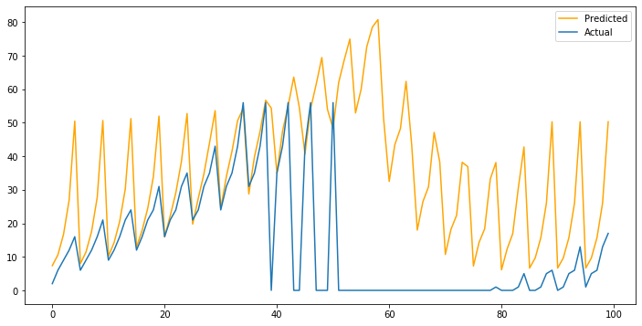

```python
best_model = models.load_model("lstm-epoch-15-valLoss-0.1680.hdf5")
# Make predictions
preds = best_model.predict(testNormX)
plt.figure(figsize = (12,6))
plt.plot(sc.inverse_transform(preds.reshape(-1, 1)), label='Predicted', color = 'orange')
plt.plot(sc.inverse_transform(testNormY.reshape(-1, 1)), label='Actual')
plt.legend()
plt.show()
```

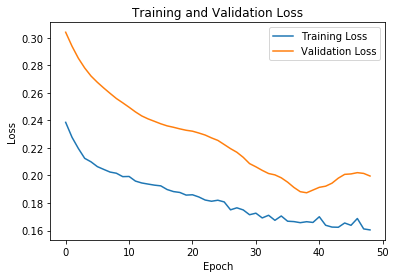

```python
plt.plot(history.history['loss'],label='Training Loss')
plt.plot(history.history['val_loss'], label='Validation Loss')
plt.ylabel('Loss')
plt.xlabel('Epoch')
plt.legend(loc='upper right')
plt.title('Training and Validation Loss')
plt.show()
```

```python
# MAE on LSTM
# Conv net accuracy
test_mae = best_model.evaluate(testNormX, testNormY)[1]
print('MAE on the test is %.3f' % test_mae)
```

```
MAE on the test is 0.132
```

#### 2.1.2) GRU

We define recurrent neural network with GRU layers with the same parameters that we have decided to pass on the previous CNN with LSTM layers. After trying out different parameters for the model, we would like to pick those paramters for our model to perform best and gain small amount of mae with 16 GRU layers, input shape being (6,1) while dropout and recurrent_dropout being 0.1. Those dropout parameter is to avoid ovefitting.Our model's activation is linear with loss function being mae, optimizer adam and metrics will measure mean_absolute_error. Since we will predict the accumulative number of admissions 1-5 weeks from the current date, our output layer will be 5. In overall, total parameters are 949 parameters which is less than ones with LSTM.

```python
# Create the model architecture (GRU)
model = Sequential()
model.add(GRU(16, input_shape = (6,1), dropout = 0.1, recurrent_dropout = 0.1))
model.add(Dense(5, activation = 'linear')) # linear becuase we're predicting the value, i.e. regression
model.compile(loss ="mae",optimizer = "adam", metrics = ["mean_absolute_error"])
model.summary()
```

```
Model: "sequential_3"
_________________________________________________________________
Layer (type)                 Output Shape              Param #
=================================================================
gru_1 (GRU)                  (None, 16)                864
_________________________________________________________________
dense_4 (Dense)              (None, 5)                 85
=================================================================
Total params: 949
Trainable params: 949
Non-trainable params: 0
_________________________________________________________________
```

```python
# Use modelcheck point to save the best model in terms of min validation error
callback_list = [EarlyStopping(monitor = 'val_loss', patience = 10, mode = 'min'),
                 ModelCheckpoint("gru-epoch-{epoch:02d}-valLoss-{val_loss:.4f}.hdf5", monitor='val_loss',verbose = 2, save_best_only = True, mode = 'min')]

history = model.fit(trainNormX, trainNormY, validation_data = (valNormX, valNormY), epochs = 100, batch_size = 24, callbacks = callback_list)
```

```
Train on 78 samples, validate on 19 samples

Epoch 00001: val_loss improved from inf to 0.30789, saving model to gru-epoch-01-valLoss-0.3079.hdf5

Epoch 00002: val_loss improved from 0.30789 to 0.29754, saving model to gru-epoch-02-valLoss-0.2975.hdf5

Epoch 00003: val_loss improved from 0.29754 to 0.28780, saving model to gru-epoch-03-valLoss-0.2878.hdf5

Epoch 00004: val_loss improved from 0.28780 to 0.27888, saving model to gru-epoch-04-valLoss-0.2789.hdf5

Epoch 00005: val_loss improved from 0.27888 to 0.27144, saving model to gru-epoch-05-valLoss-0.2714.hdf5

Epoch 00006: val_loss improved from 0.27144 to 0.26515, saving model to gru-epoch-06-valLoss-0.2651.hdf5

Epoch 00007: val_loss improved from 0.26515 to 0.25975, saving model to gru-epoch-07-valLoss-0.2597.hdf5

Epoch 00008: val_loss improved from 0.25975 to 0.25450, saving model to gru-epoch-08-valLoss-0.2545.hdf5

Epoch 00009: val_loss improved from 0.25450 to 0.25002, saving model to gru-epoch-09-valLoss-0.2500.hdf5

Epoch 00010: val_loss improved from 0.25002 to 0.24632, saving model to gru-epoch-10-valLoss-0.2463.hdf5

Epoch 00011: val_loss improved from 0.24632 to 0.24353, saving model to gru-epoch-11-valLoss-0.2435.hdf5

Epoch 00012: val_loss improved from 0.24353 to 0.24168, saving model to gru-epoch-12-valLoss-0.2417.hdf5

Epoch 00013: val_loss improved from 0.24168 to 0.23943, saving model to gru-epoch-13-valLoss-0.2394.hdf5

Epoch 00014: val_loss improved from 0.23943 to 0.23762, saving model to gru-epoch-14-valLoss-0.2376.hdf5

Epoch 00015: val_loss improved from 0.23762 to 0.23540, saving model to gru-epoch-15-valLoss-0.2354.hdf5

Epoch 00016: val_loss improved from 0.23540 to 0.23340, saving model to gru-epoch-16-valLoss-0.2334.hdf5

Epoch 00017: val_loss improved from 0.23340 to 0.23181, saving model to gru-epoch-17-valLoss-0.2318.hdf5

Epoch 00018: val_loss improved from 0.23181 to 0.23006, saving model to gru-epoch-18-valLoss-0.2301.hdf5

Epoch 00019: val_loss improved from 0.23006 to 0.22836, saving model to gru-epoch-19-valLoss-0.2284.hdf5

```

[output cut: 66 more lines]

```
Epoch 00053: val_loss did not improve from 0.18994

Epoch 00054: val_loss did not improve from 0.18994

Epoch 00055: val_loss did not improve from 0.18994

Epoch 00056: val_loss did not improve from 0.18994

Epoch 00057: val_loss did not improve from 0.18994

Epoch 00058: val_loss did not improve from 0.18994

Epoch 00059: val_loss did not improve from 0.18994

Epoch 00060: val_loss did not improve from 0.18994
```

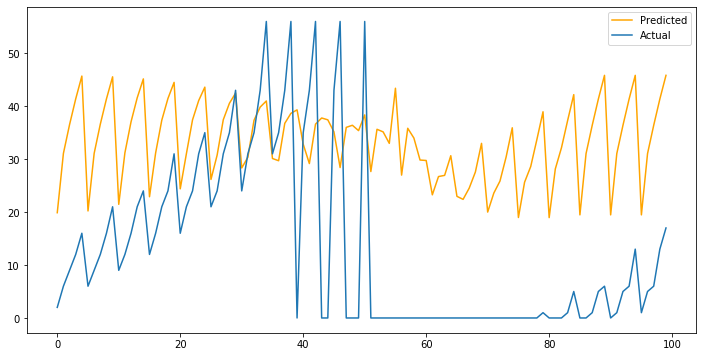

```python
# Make predictions

best_model = models.load_model("gru-epoch-60-valLoss-0.1910.hdf5")
preds = best_model.predict(testNormX)
plt.figure(figsize = (12,6))
plt.plot(sc.inverse_transform(preds.reshape(-1, 1)), label='Predicted', color = 'orange')
plt.plot(sc.inverse_transform(testNormY.reshape(-1, 1)), label='Actual')
plt.legend()
plt.show()
```

```python
# MAE on GRU
test_mae = best_model.evaluate(testNormX, testNormY)[1]
print('MAE on the test is %.3f' % test_mae)
```

```
MAE on the test is 0.135
```

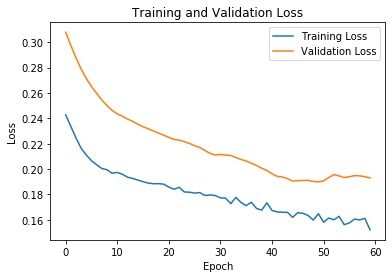

```python
plt.plot(history.history['loss'],label='Training Loss')
plt.plot(history.history['val_loss'], label='Validation Loss')
plt.ylabel('Loss')
plt.xlabel('Epoch')
plt.legend(loc='upper right')
plt.title('Training and Validation Loss')
plt.show()
```

```python
print("Below is our accumulative predictions of the best model ranging from 1 to 5 weeks forward!")
b = pd.DataFrame(np.round(sc.inverse_transform(preds),0))
b.columns = ['Week1','Week2','Week3','Week4','Week5']
display(b)
```

```
Below is our accumulative predictions of the best model ranging from 1 to 5 weeks forward!
```

|  | Week1 | Week2 | Week3 | Week4 | Week5 |
| --- | --- | --- | --- | --- | --- |
| 0 | 20.0 | 31.0 | 37.0 | 41.0 | 46.0 |
| 1 | 20.0 | 31.0 | 37.0 | 41.0 | 46.0 |
| 2 | 21.0 | 31.0 | 37.0 | 42.0 | 45.0 |
| 3 | 23.0 | 31.0 | 37.0 | 41.0 | 44.0 |
| 4 | 24.0 | 31.0 | 37.0 | 41.0 | 44.0 |
| 5 | 26.0 | 31.0 | 37.0 | 41.0 | 42.0 |
| 6 | 28.0 | 30.0 | 37.0 | 40.0 | 41.0 |
| 7 | 30.0 | 30.0 | 37.0 | 39.0 | 39.0 |
| 8 | 33.0 | 29.0 | 37.0 | 38.0 | 37.0 |
| 9 | 35.0 | 28.0 | 36.0 | 36.0 | 35.0 |
| 10 | 38.0 | 28.0 | 36.0 | 35.0 | 33.0 |
| 11 | 43.0 | 27.0 | 36.0 | 34.0 | 30.0 |
| 12 | 30.0 | 23.0 | 27.0 | 27.0 | 31.0 |
| 13 | 23.0 | 22.0 | 25.0 | 28.0 | 33.0 |
| 14 | 20.0 | 24.0 | 26.0 | 30.0 | 36.0 |
| 15 | 19.0 | 26.0 | 29.0 | 34.0 | 39.0 |
| 16 | 19.0 | 28.0 | 32.0 | 37.0 | 42.0 |
| 17 | 19.0 | 31.0 | 36.0 | 41.0 | 46.0 |
| 18 | 19.0 | 31.0 | 36.0 | 41.0 | 46.0 |
| 19 | 19.0 | 31.0 | 36.0 | 41.0 | 46.0 |

### 2.2) 1D CNN, stacking LSTM, stacking GRU

#### 2.2.1) 1D CNN

```python
# Create the model architecture (1D CNN - LSTM Stacked)
model = Sequential()
model.add(Conv1D(filters=6, kernel_size=3, strides=1, activation='relu', input_shape=(6,1)))
model.add(Flatten())
model.add(Dense(5, activation='linear'))
model.compile(loss="mae", optimizer='adam', metrics = ['mean_absolute_error'])
model.summary()
```

```
Model: "sequential_4"
_________________________________________________________________
Layer (type)                 Output Shape              Param #
=================================================================
conv1d_1 (Conv1D)            (None, 4, 6)              24
_________________________________________________________________
flatten_2 (Flatten)          (None, 24)                0
_________________________________________________________________
dense_5 (Dense)              (None, 5)                 125
=================================================================
Total params: 149
Trainable params: 149
Non-trainable params: 0
_________________________________________________________________
```

```python
# Use modelcheck point to save the best model in terms of min validation error
callback_list = [EarlyStopping(monitor = 'val_loss', patience = 5, mode = 'min'),
                 ModelCheckpoint("1DCNN-epoch-{epoch:02d}-valLoss-{val_loss:.4f}.hdf5", monitor='val_loss',verbose = 2, save_best_only = True, mode = 'min')]

history = model.fit(trainNormX, trainNormY, validation_data = (valNormX, valNormY), epochs = 100, batch_size = 24, callbacks = callback_list)
```

```
Train on 78 samples, validate on 19 samples

Epoch 00001: val_loss improved from inf to 0.32301, saving model to 1DCNN-epoch-01-valLoss-0.3230.hdf5

Epoch 00002: val_loss improved from 0.32301 to 0.31628, saving model to 1DCNN-epoch-02-valLoss-0.3163.hdf5

Epoch 00003: val_loss improved from 0.31628 to 0.30988, saving model to 1DCNN-epoch-03-valLoss-0.3099.hdf5

Epoch 00004: val_loss improved from 0.30988 to 0.30444, saving model to 1DCNN-epoch-04-valLoss-0.3044.hdf5

Epoch 00005: val_loss improved from 0.30444 to 0.29988, saving model to 1DCNN-epoch-05-valLoss-0.2999.hdf5

Epoch 00006: val_loss improved from 0.29988 to 0.29560, saving model to 1DCNN-epoch-06-valLoss-0.2956.hdf5

Epoch 00007: val_loss improved from 0.29560 to 0.29156, saving model to 1DCNN-epoch-07-valLoss-0.2916.hdf5

Epoch 00008: val_loss improved from 0.29156 to 0.28780, saving model to 1DCNN-epoch-08-valLoss-0.2878.hdf5

Epoch 00009: val_loss improved from 0.28780 to 0.28424, saving model to 1DCNN-epoch-09-valLoss-0.2842.hdf5

Epoch 00010: val_loss improved from 0.28424 to 0.28091, saving model to 1DCNN-epoch-10-valLoss-0.2809.hdf5

Epoch 00011: val_loss improved from 0.28091 to 0.27788, saving model to 1DCNN-epoch-11-valLoss-0.2779.hdf5

Epoch 00012: val_loss improved from 0.27788 to 0.27488, saving model to 1DCNN-epoch-12-valLoss-0.2749.hdf5

Epoch 00013: val_loss improved from 0.27488 to 0.27208, saving model to 1DCNN-epoch-13-valLoss-0.2721.hdf5

Epoch 00014: val_loss improved from 0.27208 to 0.26937, saving model to 1DCNN-epoch-14-valLoss-0.2694.hdf5

Epoch 00015: val_loss improved from 0.26937 to 0.26653, saving model to 1DCNN-epoch-15-valLoss-0.2665.hdf5

Epoch 00016: val_loss improved from 0.26653 to 0.26359, saving model to 1DCNN-epoch-16-valLoss-0.2636.hdf5

Epoch 00017: val_loss improved from 0.26359 to 0.26088, saving model to 1DCNN-epoch-17-valLoss-0.2609.hdf5

Epoch 00018: val_loss improved from 0.26088 to 0.25838, saving model to 1DCNN-epoch-18-valLoss-0.2584.hdf5

Epoch 00019: val_loss improved from 0.25838 to 0.25632, saving model to 1DCNN-epoch-19-valLoss-0.2563.hdf5

```

[output cut: 142 more lines]

```
Epoch 00091: val_loss improved from 0.18036 to 0.17912, saving model to 1DCNN-epoch-91-valLoss-0.1791.hdf5

Epoch 00092: val_loss improved from 0.17912 to 0.17770, saving model to 1DCNN-epoch-92-valLoss-0.1777.hdf5

Epoch 00093: val_loss improved from 0.17770 to 0.17666, saving model to 1DCNN-epoch-93-valLoss-0.1767.hdf5

Epoch 00094: val_loss did not improve from 0.17666

Epoch 00095: val_loss did not improve from 0.17666

Epoch 00096: val_loss did not improve from 0.17666

Epoch 00097: val_loss did not improve from 0.17666

Epoch 00098: val_loss did not improve from 0.17666
```

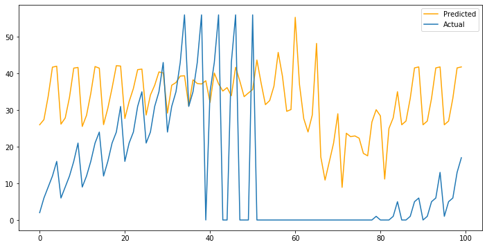

```python
# Make predictions

best_model = models.load_model("1DCNN-epoch-41-valLoss-0.1995.hdf5")
preds = best_model.predict(testNormX)
plt.figure(figsize = (12,6))
plt.plot(sc.inverse_transform(preds.reshape(-1, 1)), label='Predicted', color = 'orange')
plt.plot(sc.inverse_transform(testNormY.reshape(-1, 1)), label='Actual')
plt.legend()
plt.show()
```

```python
# MAE on 1D Conv Net
test_mae = best_model.evaluate(testNormX, testNormY)[1]
print('MAE on the test is %.3f' % test_mae)
```

```
MAE on the test is 0.130
```

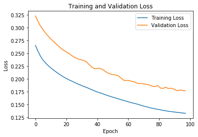

```python
plt.plot(history.history['loss'],label='Training Loss')
plt.plot(history.history['val_loss'], label='Validation Loss')
plt.ylabel('Loss')
plt.xlabel('Epoch')
plt.legend(loc='upper right')
plt.title('Training and Validation Loss')
plt.show()
```

#### 2.2.2) 1D CNN with LSTM Stacked

```python
# Create the model architecture (1D CNN - LSTM Stacked)
model = Sequential()
model.add(Conv1D(filters=6, kernel_size=3, strides=1, activation='relu', input_shape=(6,1)))
model.add(LSTM(6))
model.add(Dense(5, activation='linear'))
model.compile(loss="mae", optimizer='adam', metrics = ['mean_absolute_error'])
model.summary()
```

```
Model: "sequential_5"
_________________________________________________________________
Layer (type)                 Output Shape              Param #
=================================================================
conv1d_2 (Conv1D)            (None, 4, 6)              24
_________________________________________________________________
lstm_2 (LSTM)                (None, 6)                 312
_________________________________________________________________
dense_6 (Dense)              (None, 5)                 35
=================================================================
Total params: 371
Trainable params: 371
Non-trainable params: 0
_________________________________________________________________
```

```python
callback_list = [EarlyStopping(monitor = 'val_loss', patience = 5, mode = 'min'),
                 ModelCheckpoint("1DCNN-LTSM-epoch-{epoch:02d}-valLoss-{val_loss:.4f}.hdf5", monitor='val_loss',verbose = 2, save_best_only = True, mode = 'min')]

history = model.fit(trainNormX, trainNormY, validation_data = (valNormX, valNormY), epochs = 100, batch_size = 24, callbacks = callback_list)
```

```
Train on 78 samples, validate on 19 samples

Epoch 00001: val_loss improved from inf to 0.29898, saving model to 1DCNN-LTSM-epoch-01-valLoss-0.2990.hdf5

Epoch 00002: val_loss improved from 0.29898 to 0.29138, saving model to 1DCNN-LTSM-epoch-02-valLoss-0.2914.hdf5

Epoch 00003: val_loss improved from 0.29138 to 0.28496, saving model to 1DCNN-LTSM-epoch-03-valLoss-0.2850.hdf5

Epoch 00004: val_loss improved from 0.28496 to 0.27948, saving model to 1DCNN-LTSM-epoch-04-valLoss-0.2795.hdf5

Epoch 00005: val_loss improved from 0.27948 to 0.27466, saving model to 1DCNN-LTSM-epoch-05-valLoss-0.2747.hdf5

Epoch 00006: val_loss improved from 0.27466 to 0.27036, saving model to 1DCNN-LTSM-epoch-06-valLoss-0.2704.hdf5

Epoch 00007: val_loss improved from 0.27036 to 0.26656, saving model to 1DCNN-LTSM-epoch-07-valLoss-0.2666.hdf5

Epoch 00008: val_loss improved from 0.26656 to 0.26323, saving model to 1DCNN-LTSM-epoch-08-valLoss-0.2632.hdf5

Epoch 00009: val_loss improved from 0.26323 to 0.25990, saving model to 1DCNN-LTSM-epoch-09-valLoss-0.2599.hdf5

Epoch 00010: val_loss improved from 0.25990 to 0.25686, saving model to 1DCNN-LTSM-epoch-10-valLoss-0.2569.hdf5

Epoch 00011: val_loss improved from 0.25686 to 0.25392, saving model to 1DCNN-LTSM-epoch-11-valLoss-0.2539.hdf5

Epoch 00012: val_loss improved from 0.25392 to 0.25085, saving model to 1DCNN-LTSM-epoch-12-valLoss-0.2509.hdf5

Epoch 00013: val_loss improved from 0.25085 to 0.24796, saving model to 1DCNN-LTSM-epoch-13-valLoss-0.2480.hdf5

Epoch 00014: val_loss improved from 0.24796 to 0.24481, saving model to 1DCNN-LTSM-epoch-14-valLoss-0.2448.hdf5

Epoch 00015: val_loss improved from 0.24481 to 0.24207, saving model to 1DCNN-LTSM-epoch-15-valLoss-0.2421.hdf5

Epoch 00016: val_loss improved from 0.24207 to 0.23995, saving model to 1DCNN-LTSM-epoch-16-valLoss-0.2400.hdf5

Epoch 00017: val_loss improved from 0.23995 to 0.23804, saving model to 1DCNN-LTSM-epoch-17-valLoss-0.2380.hdf5

Epoch 00018: val_loss improved from 0.23804 to 0.23700, saving model to 1DCNN-LTSM-epoch-18-valLoss-0.2370.hdf5

Epoch 00019: val_loss improved from 0.23700 to 0.23625, saving model to 1DCNN-LTSM-epoch-19-valLoss-0.2363.hdf5

```

[output cut: 80 more lines]

```
Epoch 00060: val_loss improved from 0.17860 to 0.17783, saving model to 1DCNN-LTSM-epoch-60-valLoss-0.1778.hdf5

Epoch 00061: val_loss improved from 0.17783 to 0.17522, saving model to 1DCNN-LTSM-epoch-61-valLoss-0.1752.hdf5

Epoch 00062: val_loss improved from 0.17522 to 0.17420, saving model to 1DCNN-LTSM-epoch-62-valLoss-0.1742.hdf5

Epoch 00063: val_loss did not improve from 0.17420

Epoch 00064: val_loss did not improve from 0.17420

Epoch 00065: val_loss did not improve from 0.17420

Epoch 00066: val_loss did not improve from 0.17420

Epoch 00067: val_loss did not improve from 0.17420
```

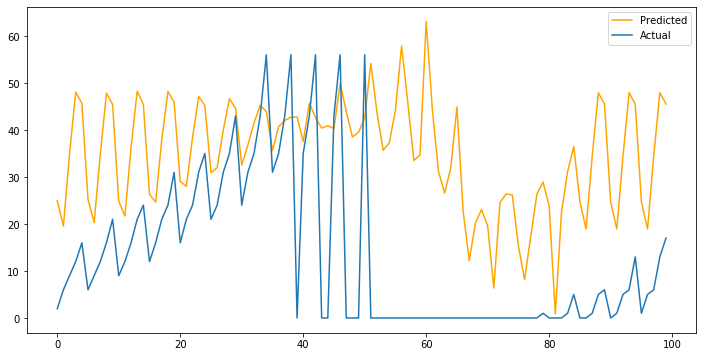

```python
best_model = models.load_model("1DCNN-LTSM-epoch-19-valLoss-0.1888.hdf5")
preds = best_model.predict(testNormX)
plt.figure(figsize = (12,6))
plt.plot(sc.inverse_transform(preds.reshape(-1, 1)), label='Predicted', color = 'orange')
plt.plot(sc.inverse_transform(testNormY.reshape(-1, 1)), label='Actual')
plt.legend()
plt.show()
```

```python
# MAE for 1D CNN with LSTM stacked
test_mae = best_model.evaluate(testNormX, testNormY)[1]
print('MAE on the test is %.3f' % test_mae)
```

```
MAE on the test is 0.136
```

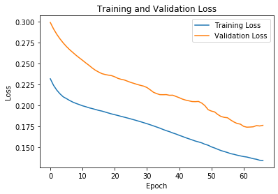

```python
plt.plot(history.history['loss'],label='Training Loss')
plt.plot(history.history['val_loss'], label='Validation Loss')
plt.ylabel('Loss')
plt.xlabel('Epoch')
plt.legend(loc='upper right')
plt.title('Training and Validation Loss')
plt.show()
```

#### 2.2.2) 1D CNN with GRU Stacked

```python
# Create the model architecture (1D CNN - GRU Stacked)
model = Sequential()
model.add(Conv1D(filters=6, kernel_size=3, strides=1, activation='relu', input_shape=(6,1)))
model.add(GRU(6))
model.add(Dense(5, activation='linear'))
model.compile(loss="mae", optimizer='adam', metrics = ['mean_absolute_error'])
model.summary()
```

```
Model: "sequential_6"
_________________________________________________________________
Layer (type)                 Output Shape              Param #
=================================================================
conv1d_3 (Conv1D)            (None, 4, 6)              24
_________________________________________________________________
gru_2 (GRU)                  (None, 6)                 234
_________________________________________________________________
dense_7 (Dense)              (None, 5)                 35
=================================================================
Total params: 293
Trainable params: 293
Non-trainable params: 0
_________________________________________________________________
```

```python
callback_list = [EarlyStopping(monitor = 'val_loss', patience = 5, mode = 'min'),
                 ModelCheckpoint("1DCNN-GRU-epoch-{epoch:02d}-valLoss-{val_loss:.4f}.hdf5", monitor='val_loss',verbose = 2, save_best_only = True, mode = 'min')]

history = model.fit(trainNormX, trainNormY, validation_data = (valNormX, valNormY), epochs = 100, batch_size = 24, callbacks = callback_list)
```

```
Train on 78 samples, validate on 19 samples

Epoch 00001: val_loss improved from inf to 0.30055, saving model to 1DCNN-GRU-epoch-01-valLoss-0.3005.hdf5

Epoch 00002: val_loss improved from 0.30055 to 0.29433, saving model to 1DCNN-GRU-epoch-02-valLoss-0.2943.hdf5

Epoch 00003: val_loss improved from 0.29433 to 0.28853, saving model to 1DCNN-GRU-epoch-03-valLoss-0.2885.hdf5

Epoch 00004: val_loss improved from 0.28853 to 0.28345, saving model to 1DCNN-GRU-epoch-04-valLoss-0.2835.hdf5

Epoch 00005: val_loss improved from 0.28345 to 0.27872, saving model to 1DCNN-GRU-epoch-05-valLoss-0.2787.hdf5

Epoch 00006: val_loss improved from 0.27872 to 0.27443, saving model to 1DCNN-GRU-epoch-06-valLoss-0.2744.hdf5

Epoch 00007: val_loss improved from 0.27443 to 0.27060, saving model to 1DCNN-GRU-epoch-07-valLoss-0.2706.hdf5

Epoch 00008: val_loss improved from 0.27060 to 0.26701, saving model to 1DCNN-GRU-epoch-08-valLoss-0.2670.hdf5

Epoch 00009: val_loss improved from 0.26701 to 0.26355, saving model to 1DCNN-GRU-epoch-09-valLoss-0.2636.hdf5

Epoch 00010: val_loss improved from 0.26355 to 0.26046, saving model to 1DCNN-GRU-epoch-10-valLoss-0.2605.hdf5

Epoch 00011: val_loss improved from 0.26046 to 0.25757, saving model to 1DCNN-GRU-epoch-11-valLoss-0.2576.hdf5

Epoch 00012: val_loss improved from 0.25757 to 0.25473, saving model to 1DCNN-GRU-epoch-12-valLoss-0.2547.hdf5

Epoch 00013: val_loss improved from 0.25473 to 0.25235, saving model to 1DCNN-GRU-epoch-13-valLoss-0.2523.hdf5

Epoch 00014: val_loss improved from 0.25235 to 0.25011, saving model to 1DCNN-GRU-epoch-14-valLoss-0.2501.hdf5

Epoch 00015: val_loss improved from 0.25011 to 0.24802, saving model to 1DCNN-GRU-epoch-15-valLoss-0.2480.hdf5

Epoch 00016: val_loss improved from 0.24802 to 0.24581, saving model to 1DCNN-GRU-epoch-16-valLoss-0.2458.hdf5

Epoch 00017: val_loss improved from 0.24581 to 0.24332, saving model to 1DCNN-GRU-epoch-17-valLoss-0.2433.hdf5

Epoch 00018: val_loss improved from 0.24332 to 0.24109, saving model to 1DCNN-GRU-epoch-18-valLoss-0.2411.hdf5

Epoch 00019: val_loss improved from 0.24109 to 0.23843, saving model to 1DCNN-GRU-epoch-19-valLoss-0.2384.hdf5

```

[output cut: 138 more lines]

```
Epoch 00089: val_loss did not improve from 0.16384

Epoch 00090: val_loss improved from 0.16384 to 0.16138, saving model to 1DCNN-GRU-epoch-90-valLoss-0.1614.hdf5

Epoch 00091: val_loss improved from 0.16138 to 0.16094, saving model to 1DCNN-GRU-epoch-91-valLoss-0.1609.hdf5

Epoch 00092: val_loss did not improve from 0.16094

Epoch 00093: val_loss did not improve from 0.16094

Epoch 00094: val_loss did not improve from 0.16094

Epoch 00095: val_loss did not improve from 0.16094

Epoch 00096: val_loss did not improve from 0.16094
```

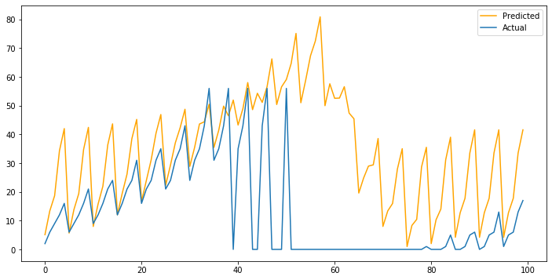

```python
# Make predictions
best_model = models.load_model("1DCNN-GRU-epoch-49-valLoss-0.1954.hdf5")
preds = model.predict(testNormX)
plt.figure(figsize = (12,6))
plt.plot(sc.inverse_transform(preds.reshape(-1, 1)), label='Predicted', color = 'orange')
plt.plot(sc.inverse_transform(testNormY.reshape(-1, 1)), label='Actual')
plt.legend()
plt.show()
```

```python
# MAE for 1D CNN with GRU stacked
test_mae = best_model.evaluate(testNormX, testNormY)[1]
print('MAE on the test is %.3f' % test_mae)
```

```
MAE on the test is 0.127
```

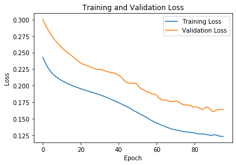

```python
plt.plot(history.history['loss'],label='Training Loss')
plt.plot(history.history['val_loss'], label='Validation Loss')
plt.ylabel('Loss')
plt.xlabel('Epoch')
plt.legend(loc='upper right')
plt.title('Training and Validation Loss')
plt.show()
```

Comparing the MAE 1D CNN vs. 1D CNN with LSTM vs. 1D CNN with GRU, we notice that the last model yeilds the lowest MAE (1D CNN with GRU).

### 2.3) Deep Neural Network

#### 2.3.1) Pre-Processing

```python
# Check for NaNs
print(df.isna().sum())
```

```
ExpStartDate        0
AdmittedNum         0
AppliedNum          0
WeeksBeforeStart    0
Budget              0
dtype: int64
```

We explored several different models with different no. of input features. The best Deep NN model resulted when we used the same data as from 2.1) & 2.3) above.

```python
# Build the Deep NN model
model = Sequential()
model.add(Dense(32, activation = 'relu', input_dim = trainNormX.shape[1]))
model.add(Dropout(0.2))
model.add(Dense(16, activation = 'relu'))
model.add(Dropout(0.2))
model.add(Dense(5, activation = "linear"))

model.compile(loss='mae', optimizer='adam', metrics=['mean_absolute_error'])

model.summary()
```

```
Model: "sequential_7"
_________________________________________________________________
Layer (type)                 Output Shape              Param #
=================================================================
dense_8 (Dense)              (None, 32)                224
_________________________________________________________________
dropout_1 (Dropout)          (None, 32)                0
_________________________________________________________________
dense_9 (Dense)              (None, 16)                528
_________________________________________________________________
dropout_2 (Dropout)          (None, 16)                0
_________________________________________________________________
dense_10 (Dense)             (None, 5)                 85
=================================================================
Total params: 837
Trainable params: 837
Non-trainable params: 0
_________________________________________________________________
```

```python
trainNormXdnn = np.reshape(trainNormX, (trainNormX.shape[0], trainNormX.shape[1]))
valNormXdnn = np.reshape(valNormX, (valNormX.shape[0], valNormX.shape[1]))
testNormXdnn = np.reshape(testNormX, (testNormX.shape[0], testNormX.shape[1]))
print(trainNormXdnn.shape, valNormXdnn.shape, testNormXdnn.shape)
```

```
(78, 6) (19, 6) (20, 6)
```

```python
callback_list = [ EarlyStopping(monitor = 'val_loss', patience = 5, mode = 'min'),
                 ModelCheckpoint("deepNN-epoch-{epoch:02d}-valLoss-{val_loss:.4f}.hdf5", monitor='val_loss',verbose = 2, save_best_only = True, mode = 'min')]
```

```python
history = model.fit(trainNormXdnn, trainNormY, batch_size = 128, epochs = 100, validation_data=(valNormXdnn, valNormY), callbacks = callback_list)
```

```
Train on 78 samples, validate on 19 samples

Epoch 00001: val_loss improved from inf to 0.31767, saving model to deepNN-epoch-01-valLoss-0.3177.hdf5

Epoch 00002: val_loss improved from 0.31767 to 0.31402, saving model to deepNN-epoch-02-valLoss-0.3140.hdf5

Epoch 00003: val_loss improved from 0.31402 to 0.31041, saving model to deepNN-epoch-03-valLoss-0.3104.hdf5

Epoch 00004: val_loss improved from 0.31041 to 0.30676, saving model to deepNN-epoch-04-valLoss-0.3068.hdf5

Epoch 00005: val_loss improved from 0.30676 to 0.30319, saving model to deepNN-epoch-05-valLoss-0.3032.hdf5

Epoch 00006: val_loss improved from 0.30319 to 0.29954, saving model to deepNN-epoch-06-valLoss-0.2995.hdf5

Epoch 00007: val_loss improved from 0.29954 to 0.29601, saving model to deepNN-epoch-07-valLoss-0.2960.hdf5

Epoch 00008: val_loss improved from 0.29601 to 0.29245, saving model to deepNN-epoch-08-valLoss-0.2925.hdf5

Epoch 00009: val_loss improved from 0.29245 to 0.28899, saving model to deepNN-epoch-09-valLoss-0.2890.hdf5

Epoch 00010: val_loss improved from 0.28899 to 0.28563, saving model to deepNN-epoch-10-valLoss-0.2856.hdf5

Epoch 00011: val_loss improved from 0.28563 to 0.28260, saving model to deepNN-epoch-11-valLoss-0.2826.hdf5

Epoch 00012: val_loss improved from 0.28260 to 0.27963, saving model to deepNN-epoch-12-valLoss-0.2796.hdf5

Epoch 00013: val_loss improved from 0.27963 to 0.27685, saving model to deepNN-epoch-13-valLoss-0.2769.hdf5

Epoch 00014: val_loss improved from 0.27685 to 0.27430, saving model to deepNN-epoch-14-valLoss-0.2743.hdf5

Epoch 00015: val_loss improved from 0.27430 to 0.27189, saving model to deepNN-epoch-15-valLoss-0.2719.hdf5

Epoch 00016: val_loss improved from 0.27189 to 0.26951, saving model to deepNN-epoch-16-valLoss-0.2695.hdf5

Epoch 00017: val_loss improved from 0.26951 to 0.26750, saving model to deepNN-epoch-17-valLoss-0.2675.hdf5

Epoch 00018: val_loss improved from 0.26750 to 0.26570, saving model to deepNN-epoch-18-valLoss-0.2657.hdf5

Epoch 00019: val_loss improved from 0.26570 to 0.26390, saving model to deepNN-epoch-19-valLoss-0.2639.hdf5

```

[output cut: 146 more lines]

```
Epoch 00093: val_loss improved from 0.19680 to 0.19619, saving model to deepNN-epoch-93-valLoss-0.1962.hdf5

Epoch 00094: val_loss improved from 0.19619 to 0.19552, saving model to deepNN-epoch-94-valLoss-0.1955.hdf5

Epoch 00095: val_loss improved from 0.19552 to 0.19479, saving model to deepNN-epoch-95-valLoss-0.1948.hdf5

Epoch 00096: val_loss improved from 0.19479 to 0.19406, saving model to deepNN-epoch-96-valLoss-0.1941.hdf5

Epoch 00097: val_loss improved from 0.19406 to 0.19328, saving model to deepNN-epoch-97-valLoss-0.1933.hdf5

Epoch 00098: val_loss improved from 0.19328 to 0.19242, saving model to deepNN-epoch-98-valLoss-0.1924.hdf5

Epoch 00099: val_loss improved from 0.19242 to 0.19172, saving model to deepNN-epoch-99-valLoss-0.1917.hdf5

Epoch 00100: val_loss improved from 0.19172 to 0.19127, saving model to deepNN-epoch-100-valLoss-0.1913.hdf5
```

```python
best_model = models.load_model('deepNN-epoch-22-valLoss-0.1814.hdf5')
print('MAE on the test is %.3f' % best_model.evaluate(testNormXdnn, testNormY)[1])
```

[output not shown]

```
<function matplotlib.pyplot.show(*args, **kw)>
```

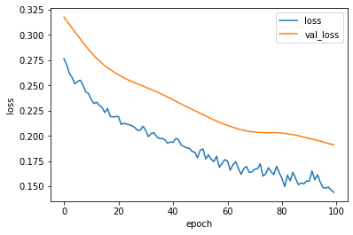

```python
plt.plot(history.history['loss'],label='loss')
plt.plot(history.history['val_loss'], label='val_loss')
plt.ylabel('loss')
plt.xlabel('epoch')
plt.legend()
plt.show
```

```python
# Make predictions
best_model = models.load_model("1DCNN-GRU-epoch-49-valLoss-0.1954.hdf5")
preds = model.predict(testNormXdnn)
print("Deep NN Predictions")
preds
```

```
array([[0.11226957, 0.15675709, 0.16103938, 0.17782634, 0.24707974],
       [0.11612038, 0.15887874, 0.16467783, 0.17785154, 0.24803609],
       [0.13163602, 0.16855931, 0.17940651, 0.18666112, 0.26509187],
       [0.14520673, 0.173128  , 0.19142765, 0.20100673, 0.2828991 ],
       [0.15768373, 0.17790179, 0.20340031, 0.20769604, 0.29092145],
       [0.17570205, 0.189652  , 0.22058348, 0.21205401, 0.3032969 ],
       [0.19108102, 0.19905771, 0.23503426, 0.21897988, 0.31639022],
       [0.19504964, 0.19935782, 0.23898862, 0.22756387, 0.32415414],
       [0.21403345, 0.20918481, 0.25576663, 0.22662646, 0.32829848],
       [0.22189619, 0.21383694, 0.26158628, 0.22849016, 0.33425486],
       [0.23622838, 0.21956302, 0.2730467 , 0.20861393, 0.3162949 ],
       [0.2702094 , 0.23415785, 0.30304503, 0.19375716, 0.31139746],
       [0.0470178 , 0.09677512, 0.10683578, 0.16212933, 0.17174074],
       [0.03041805, 0.06001141, 0.07364946, 0.0633411 , 0.03829671],
       [0.04252344, 0.11184251, 0.0947336 , 0.12032401, 0.14117554],
       [0.02505441, 0.07068522, 0.0357349 , 0.13638578, 0.11748609],
       [0.03136504, 0.08046466, 0.07612868, 0.16712622, 0.15310363],
       [0.10844258, 0.15499878, 0.156856  , 0.17330731, 0.24137387],
       [0.10844257, 0.15499878, 0.15685599, 0.1733073 , 0.24137385],
       [0.10844257, 0.15499878, 0.15685599, 0.1733073 , 0.24137385]],
      dtype=float32)
```

### 2.4 Comment on the performance of the models

The three models had the following MAEs:

1. RNN - LTSM = 0.132
2. RNN - GRU = 0.135
3. 1D CNN = 0.130
4. 1D CNN with LTSM = 0.136
5. 1D CNN with GRU = 0.127
6. DeepNN = 0.106

According to the MAEs, the best model for predicting admissions is the Deep NN and second best model is the 1D CNN stacked with GRU